# Larval zebrafish Trust STK_50 min

# Detailed output files

Detailed peptide lists, fitted model tables, cycle-QC diagnostics, and paired 50-versus-100-ms measurements are saved as CSV files in:

/Users/rzidan/Documents/GitHub/larval-zebrafish-Trust-STK-/results/50min_exposure_QC

These detailed objects are intentionally not printed as raw console output in the main report.

## Global Signal Intensity

For a global signal intensity across all samples/groups, few figures can be plotted based on the *Slope_Transformed* values.

### Global Violin Plots

We will plot violin figures to examine global signal differences between groups/samples.

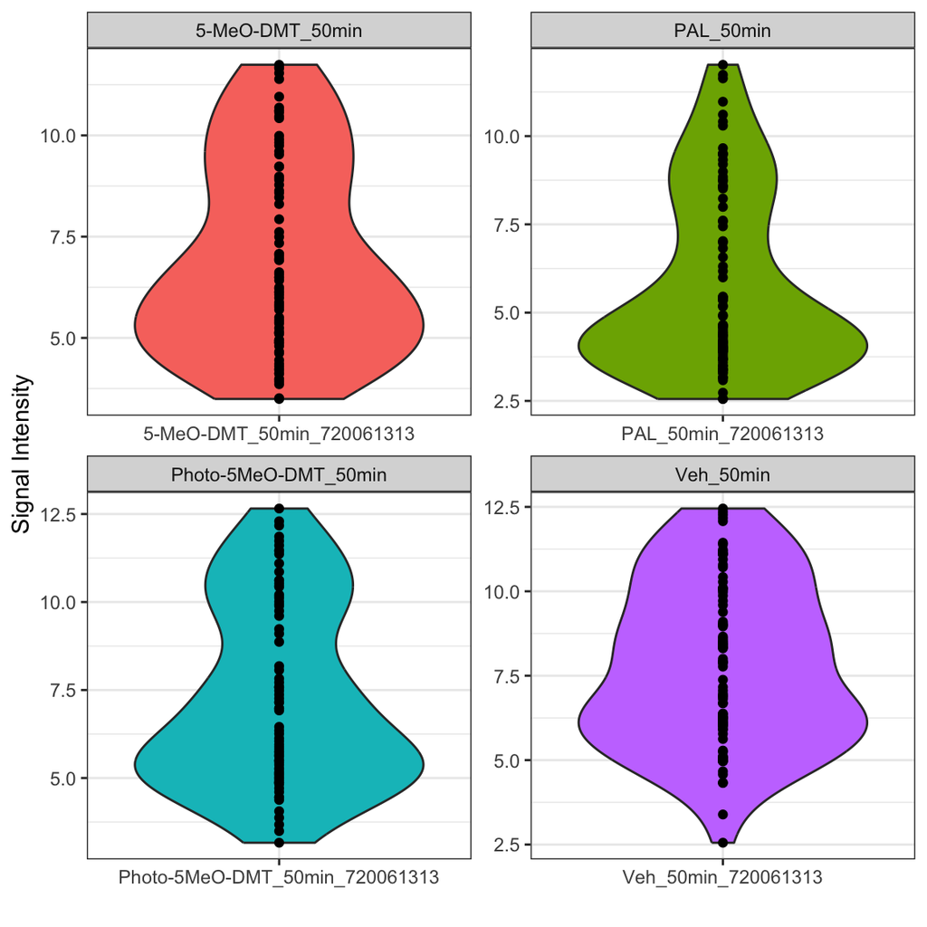

Violin Plots for signal intensity Distribution Across Groups for all replicates

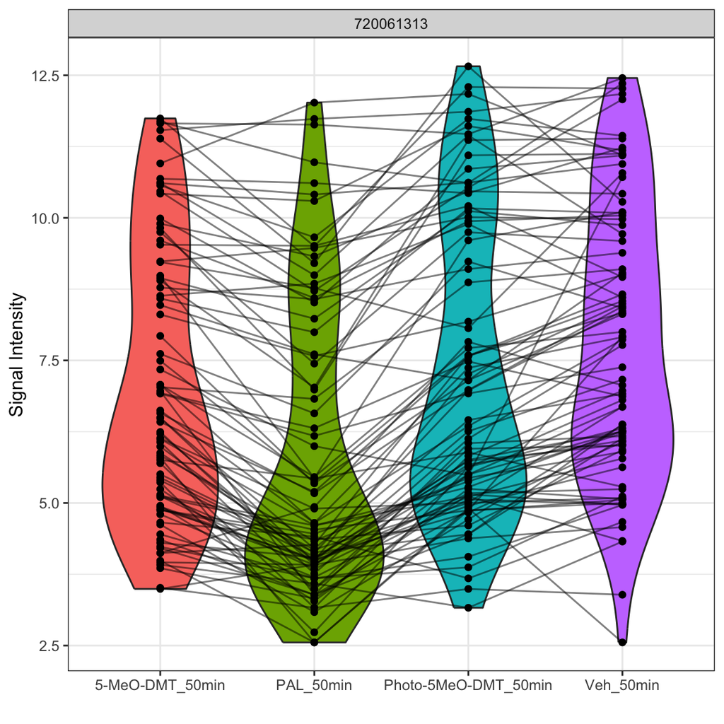

Violin Plots for signal intensity Distribution Across Chips for all replicates

### Global Heatmaps

The heatmap represent all the peptides present on the chip except the positive/internal controls and peptides that failed to pass QC. The heatmaps are scaled by row to highlight the peptide signal differences across the samples. A hierarchical unsupervised clustering is applied both on the peptides and the samples to group potentially similar signatures.

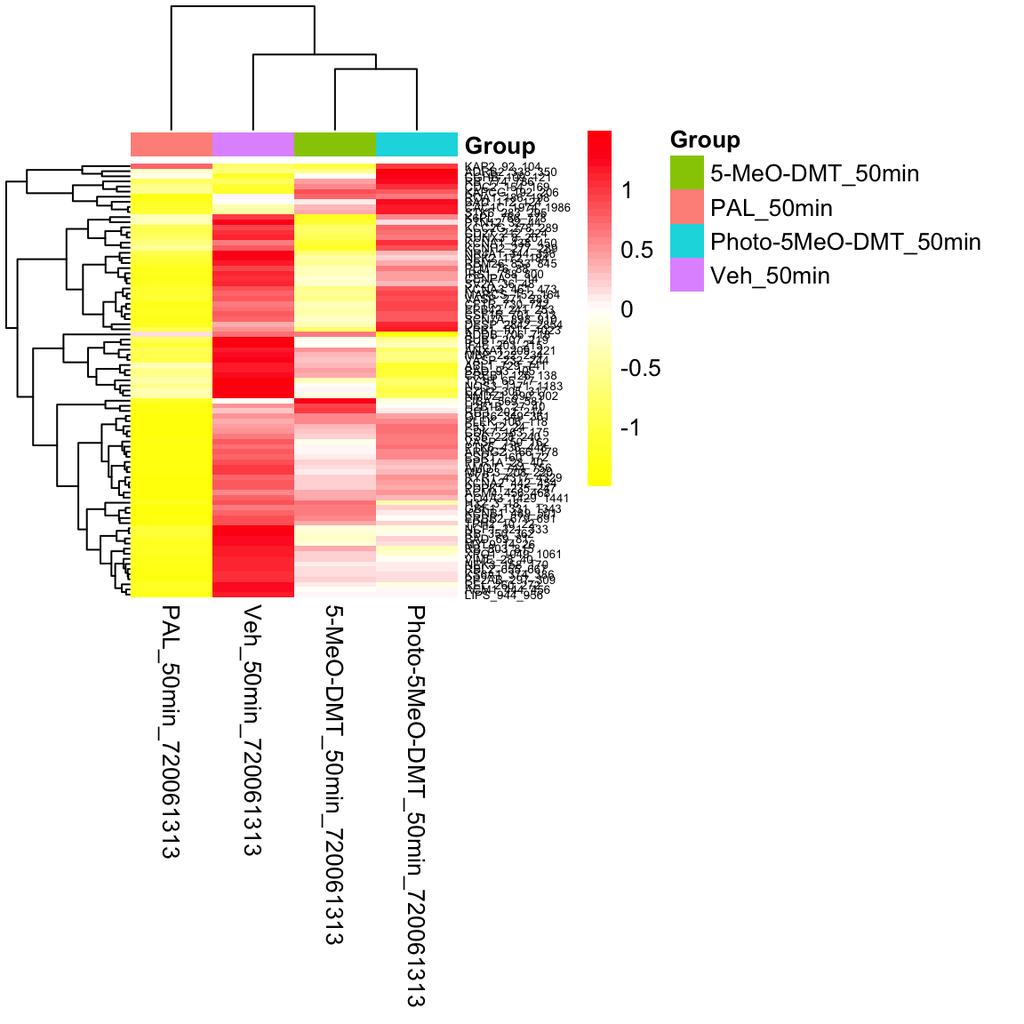

Row and chip normalized intensity values for the selected peptides

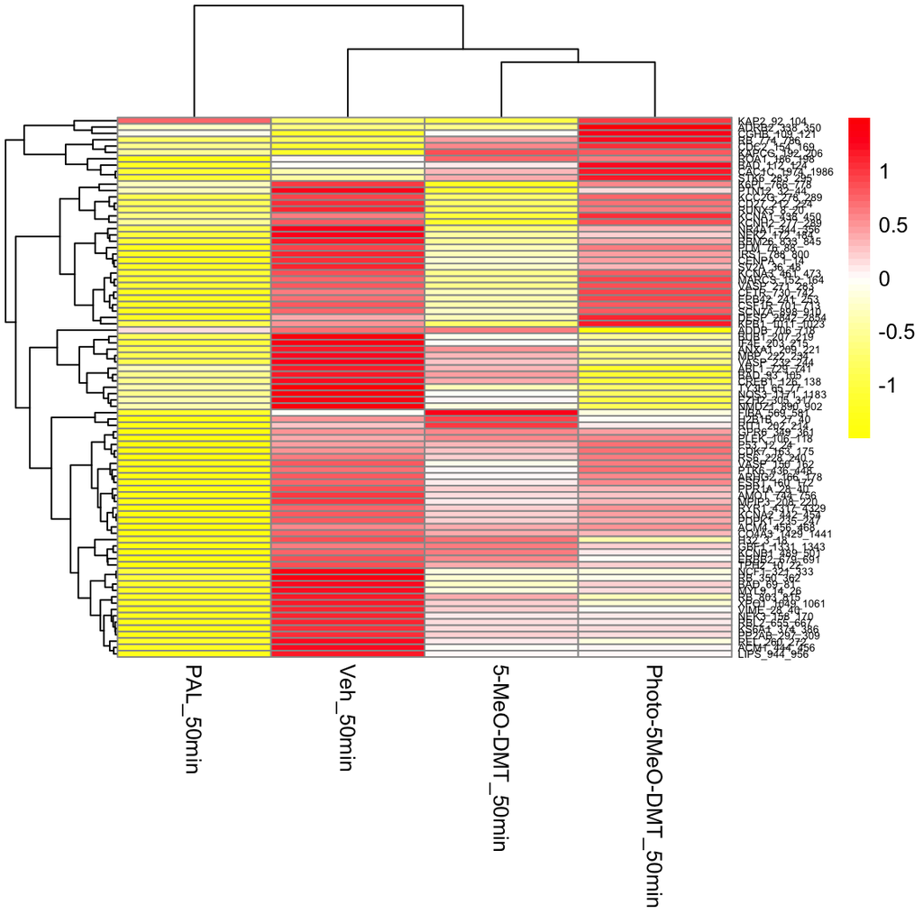

Row and group normalized intensity values for the selected peptides

## Group Comparison

Group comparisons use the corrected QC branch. Low-signal filtering uses observed 50-ms signal with a threshold of 3. Exposure-response linearity requires R² ≥0.8 using observed measurements through 50 ms.

[figure not shown]

Heatmap of pairwise group comparison

### 5-MeO-DMT_50min vs Veh_50min

#### Heatmap

After applying the *Filtering Parameters* for this group comparison, only *73*/141 peptides carried forward in the analysis (i.e. *73 hits*). Below are some figures to visualize the differences between these samples for considering these *hits*.

#### Violin Plot

Below, the violin plot visualizes the distribution of selected peptides for the analysis.

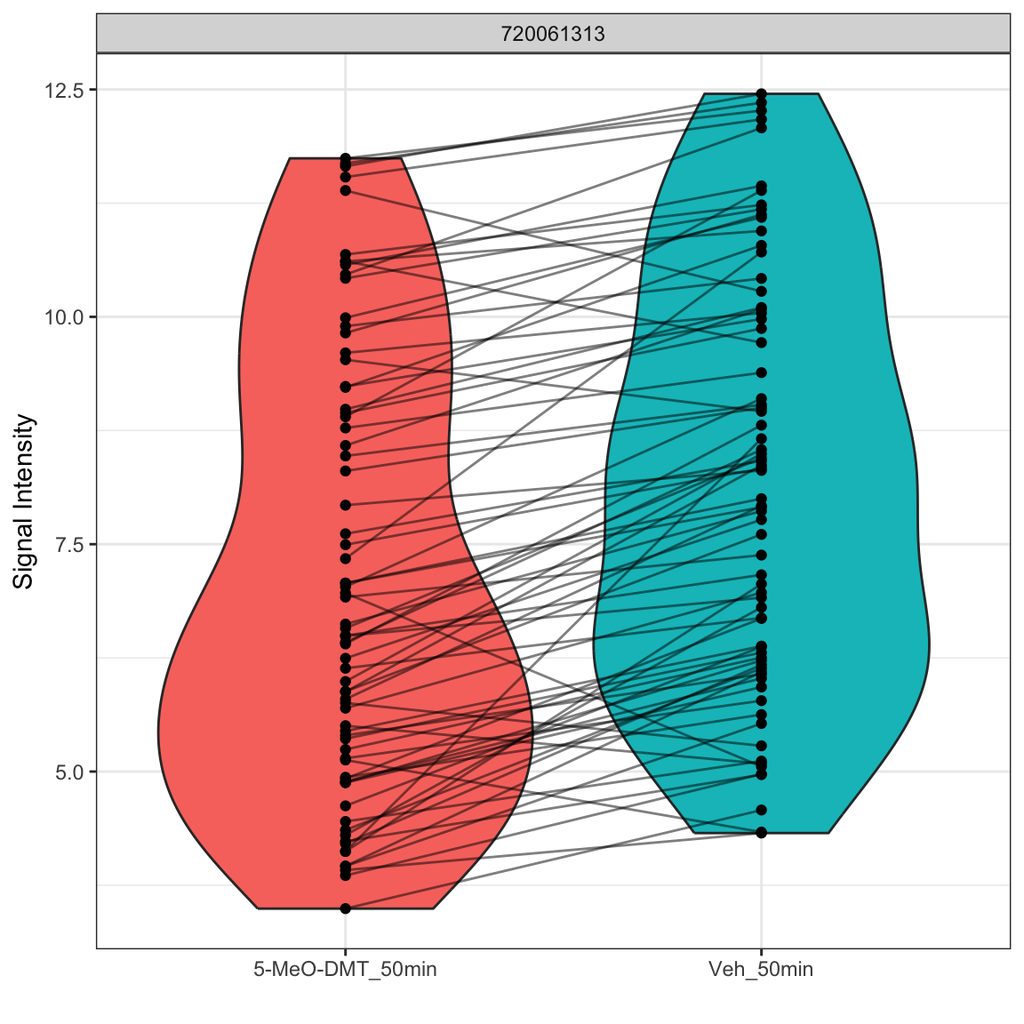

Violin plot of two groups

#### Waterfall Plot

This waterfall represents the log2 fold changes between the two groups at each peptide.

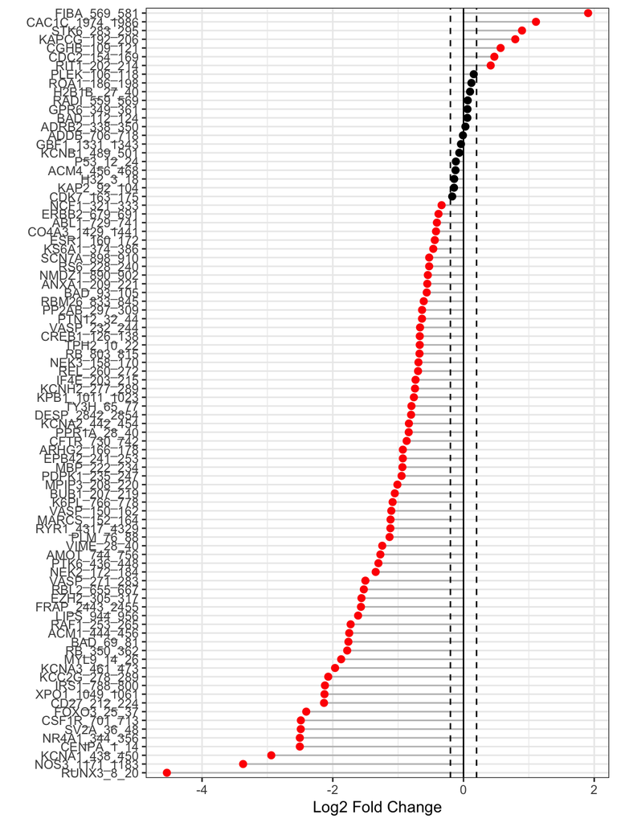

Waterfall Plot to show the distribution of change in peptide phosphorylation

#### Upstream Kinase Analysis

The lab carefully curated and mapped the kinases that can act and phosphorylate each peptide present on the chip. This was achieved by using multiple sources including GPS 3.0, Kinexus Phosphonet, PhosphoELM and PhosphoSite Plus. Based on that association between peptides and kinases, a random sampling analysis is performed for these hits. The basic idea of *KRSA* is: For each iteration (*2000* iterations performed in this analysis), the same number of hits are randomly selected from the total 141/or 193 peptides present on the chip. Predicted kinases are then mapped to this sample list of peptides and number of kinases are determined. The kinase count from the actual hits and random sampling is then compared to determine the significance.

| Kinase | AvgZ |
| --- | --- |
| PKG | 1.7225 |
| MARK | 1.5625 |
| HAL | 1.3800 |
| PKA | 1.1450 |
| CAMK2 | 1.1325 |
| CAMK1 | 1.0000 |
| MOS | 0.9850 |
| PKCI | 0.9825 |
| BRSK | 0.9825 |
| TAO | 0.9750 |
| NMO | -3.5625 |
| JNK | -3.7000 |
| P38 | -3.7475 |
| DMPK | -3.9075 |
| ERK | -4.6800 |
| DYRK | -4.7950 |
| CDK | -4.9600 |
| PEK | -4.9900 |
| PLK | -5.2625 |
| PKCA | -7.0300 |

| Method | NumberOfPeptides |
| --- | --- |
| meanLFC.0.15 | 75 |
| meanLFC.0.2 | 73 |
| meanLFC.0.3 | 73 |
| meanLFC.0.4 | 71 |
| 720061313.0.15 | 75 |
| 720061313.0.2 | 73 |
| 720061313.0.3 | 73 |
| 720061313.0.4 | 71 |

#### Z Scores Plot

We will plot the individual and averaged Z scores using both the across and within chip analyses.

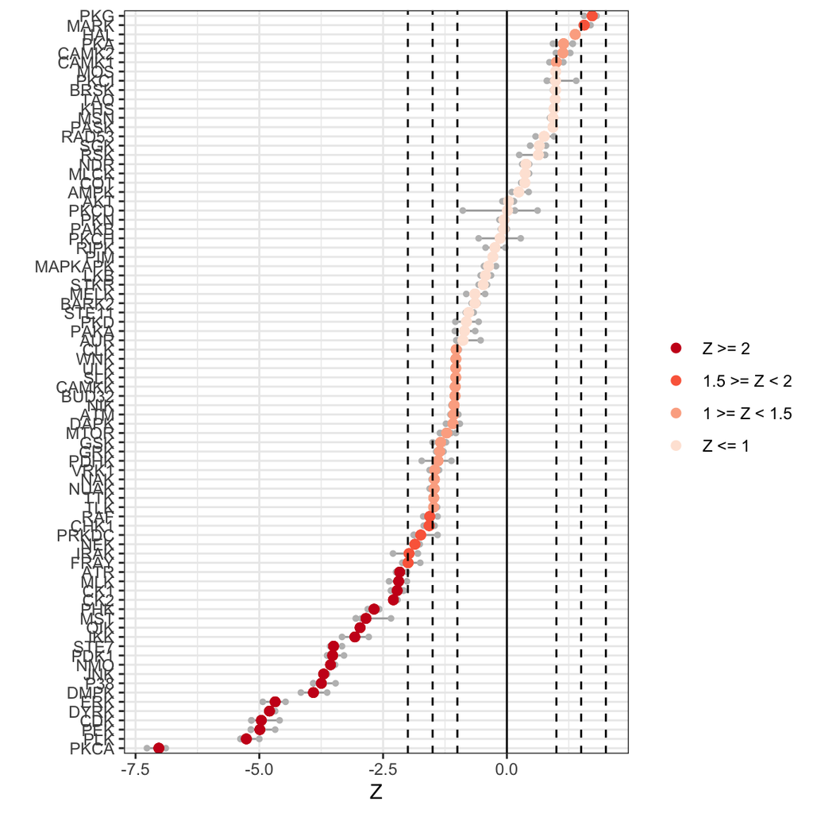

Waterfall plot of the Z Scores of each kinase family

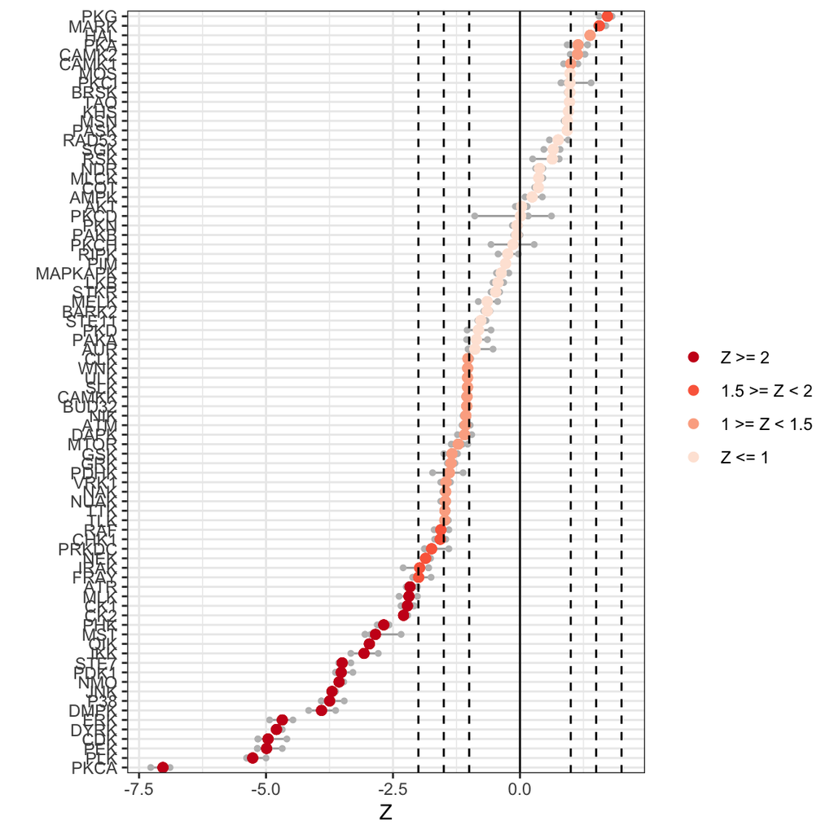

Waterfall plot of the Z Scores of each kinase family

#### Reverse KRSA Plot

We will use the reverse KRSA plot function, to plot the log2 fold change values for all peptides mapped to kinase hits. This will help us examine the activity of the kinase

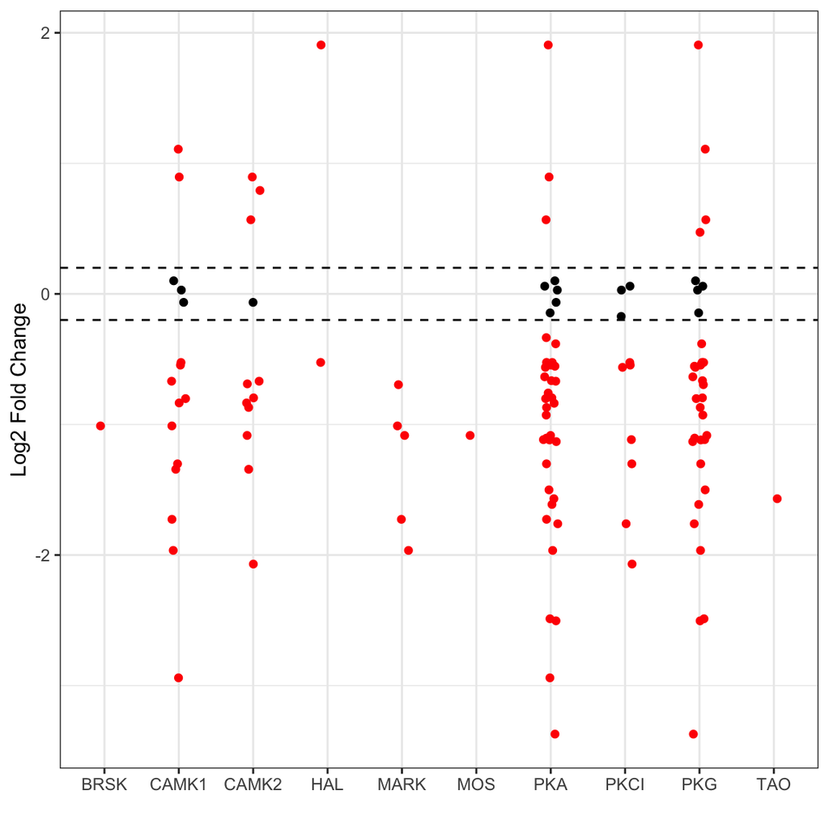

Kinase Activity summary for each kinase family based on peptide phosphorylation

#### Coverage Plot

To view the coverage of kinases across the full list of peptides on the chip, we will use the coverage plot function

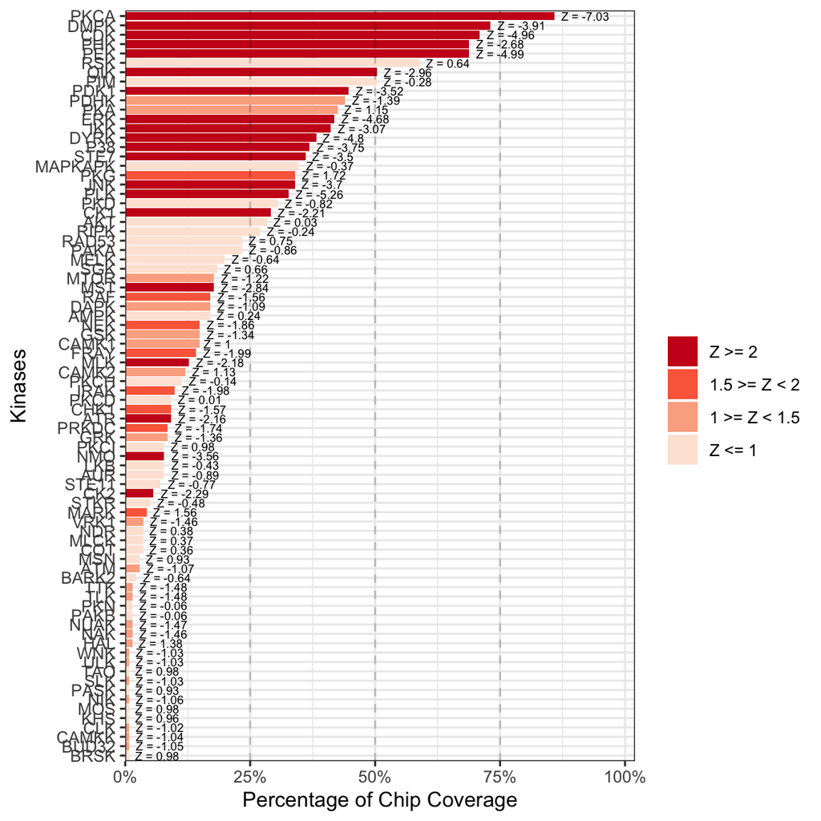

Percentage of peptides each kinase family phosphorylates

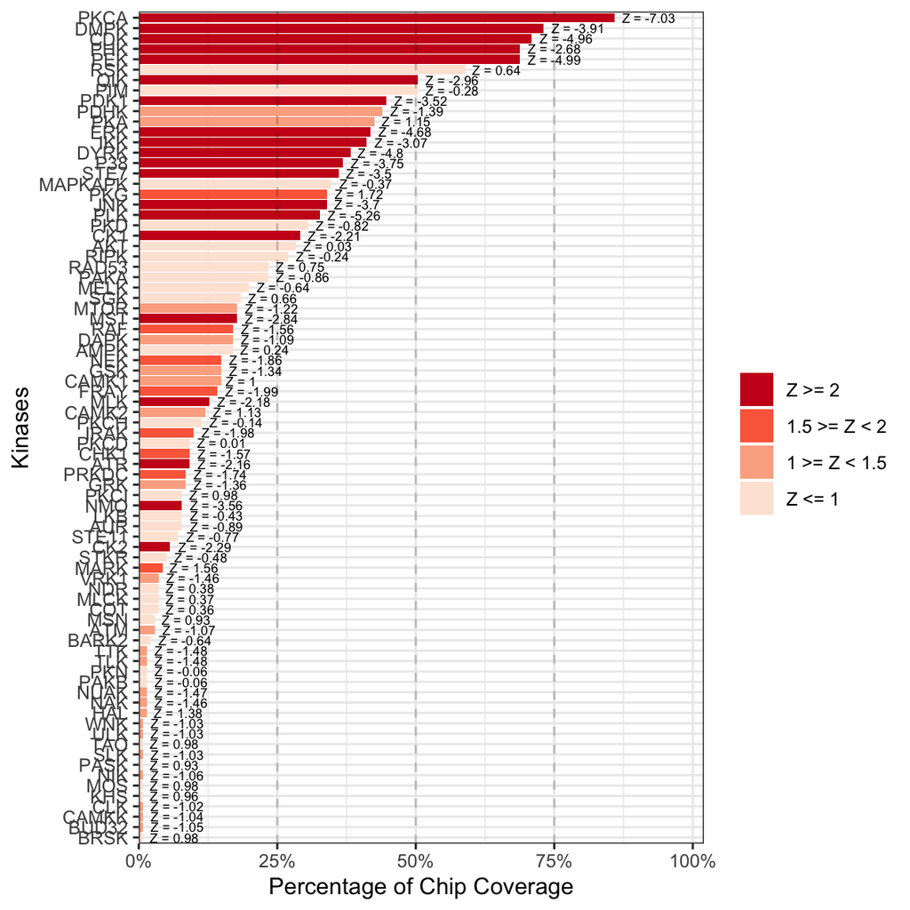

Percentage of peptides each kinase family phosphorylates

#### Ball Model Network

We will view the ball model network function, to generate a model representing the protein-protein interactions between kinases

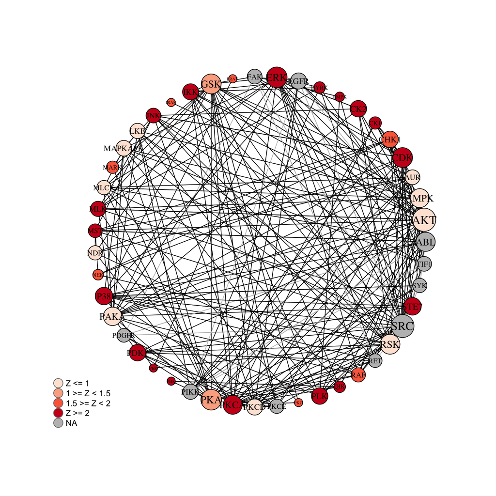

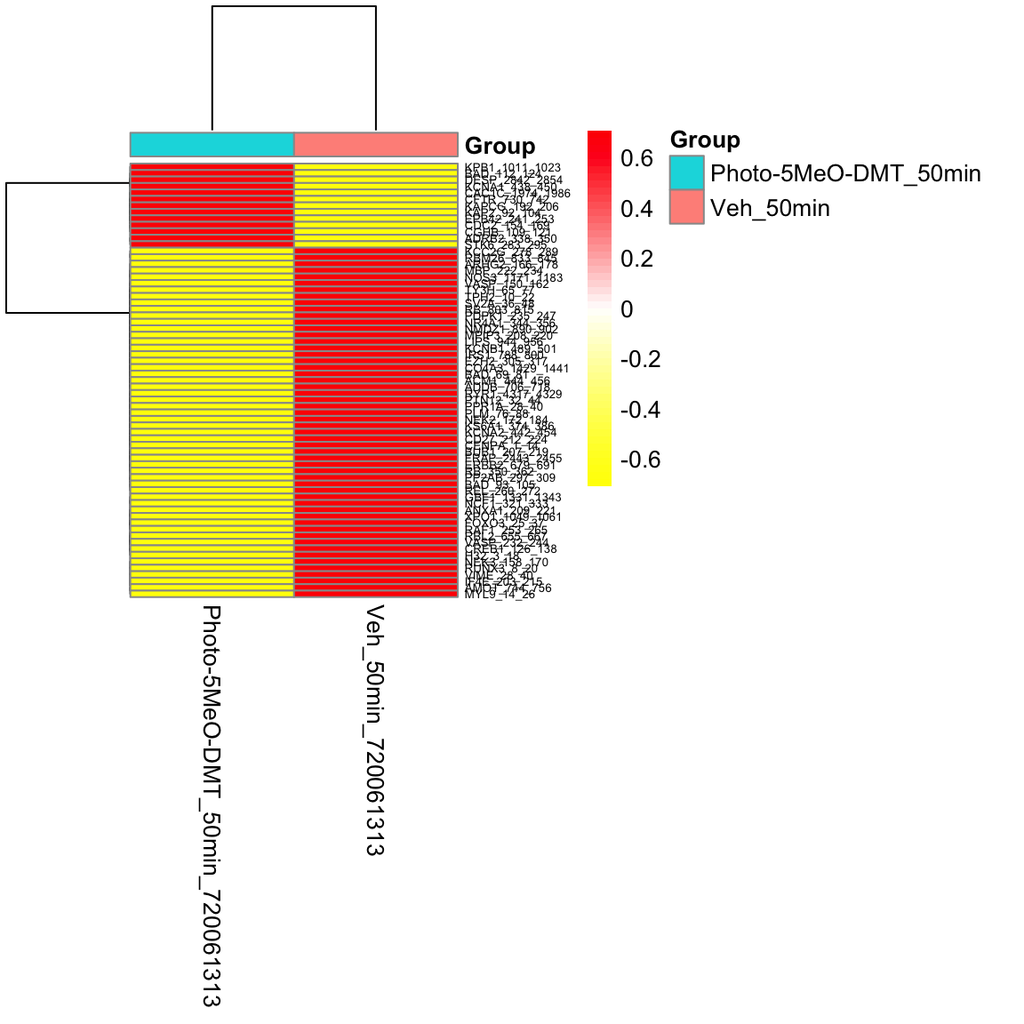

Heatmap of pairwise group comparison

### Photo-5MeO-DMT_50min vs Veh_50min

#### Heatmap

After applying the *Filtering Parameters* for this group comparison, only *67*/141 peptides carried forward in the analysis (i.e. *67 hits*). Below are some figures to visualize the differences between these samples for considering these *hits*.

#### Violin Plot

Below, the violin plot visualizes the distribution of selected peptides for the analysis.

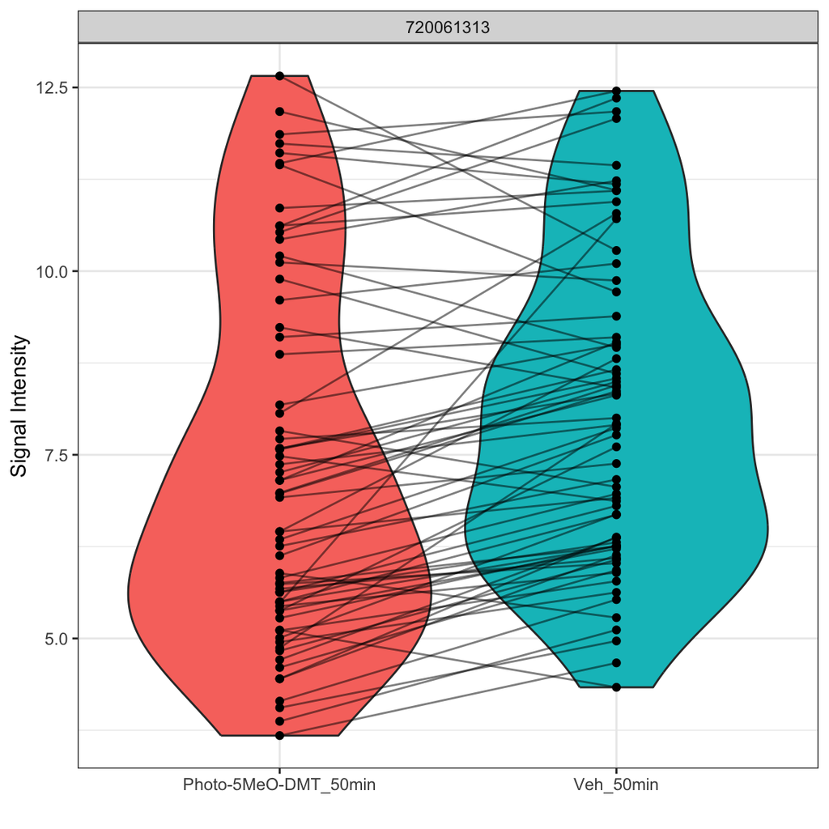

Violin plot of two groups

#### Waterfall Plot

This waterfall represents the log2 fold changes between the two groups at each peptide.

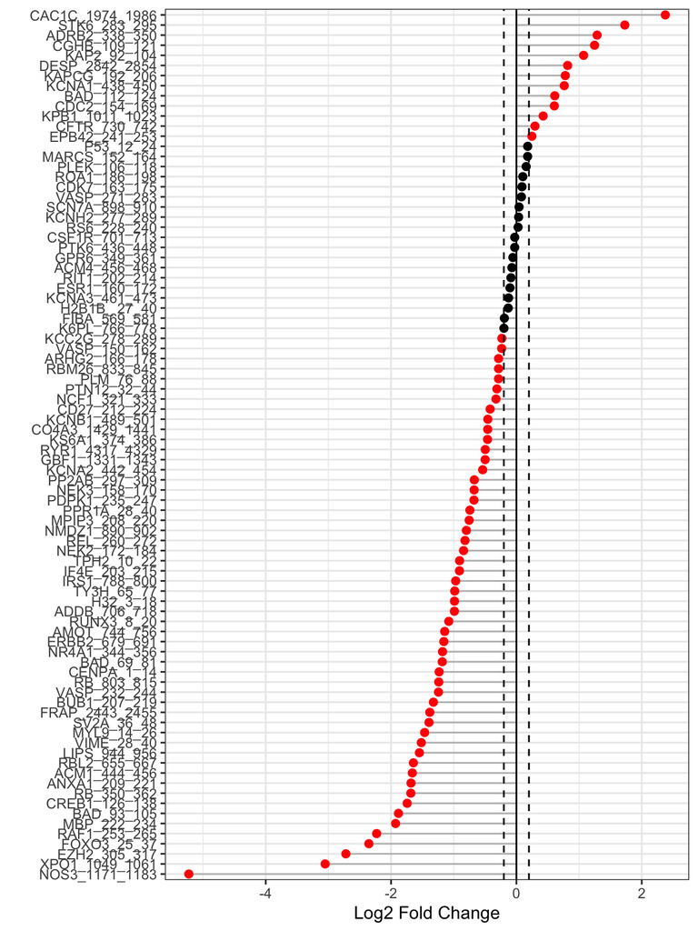

Waterfall Plot to show the distribution of change in peptide phosphorylation

#### Upstream Kinase Analysis

The lab carefully curated and mapped the kinases that can act and phosphorylate each peptide present on the chip. This was achieved by using multiple sources including GPS 3.0, Kinexus Phosphonet, PhosphoELM and PhosphoSite Plus. Based on that association between peptides and kinases, a random sampling analysis is performed for these hits. The basic idea of *KRSA* is: For each iteration (*2000* iterations performed in this analysis), the same number of hits are randomly selected from the total 141/or 193 peptides present on the chip. Predicted kinases are then mapped to this sample list of peptides and number of kinases are determined. The kinase count from the actual hits and random sampling is then compared to determine the significance.

| Kinase | AvgZ |
| --- | --- |
| CAMK2 | 1.3050 |
| MSN | 1.2500 |
| CAMK1 | 1.1575 |
| TAO | 1.1175 |
| BRSK | 1.1075 |
| SGK | 0.8325 |
| AMPK | 0.8150 |
| RAD53 | 0.8025 |
| NDR | 0.6650 |
| RSK | 0.6575 |
| DYRK | -3.1225 |
| NMO | -3.1350 |
| ERK | -3.1450 |
| P38 | -3.2325 |
| JNK | -3.2725 |
| IKK | -3.7400 |
| CDK | -4.1100 |
| PEK | -4.7175 |
| PLK | -4.7750 |
| PKCA | -5.8500 |

| Method | NumberOfPeptides |
| --- | --- |
| meanLFC.0.15 | 72 |
| meanLFC.0.2 | 67 |
| meanLFC.0.3 | 60 |
| meanLFC.0.4 | 58 |
| 720061313.0.15 | 72 |
| 720061313.0.2 | 67 |
| 720061313.0.3 | 60 |
| 720061313.0.4 | 58 |

#### Z Scores Plot

We will plot the individual and averaged Z scores using both the across and within chip analyses.

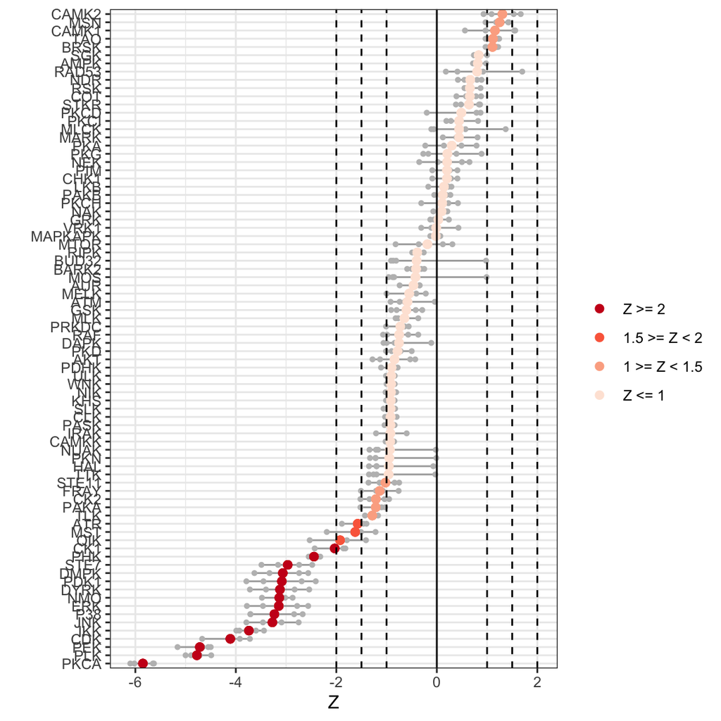

Waterfall plot of the Z Scores of each kinase family

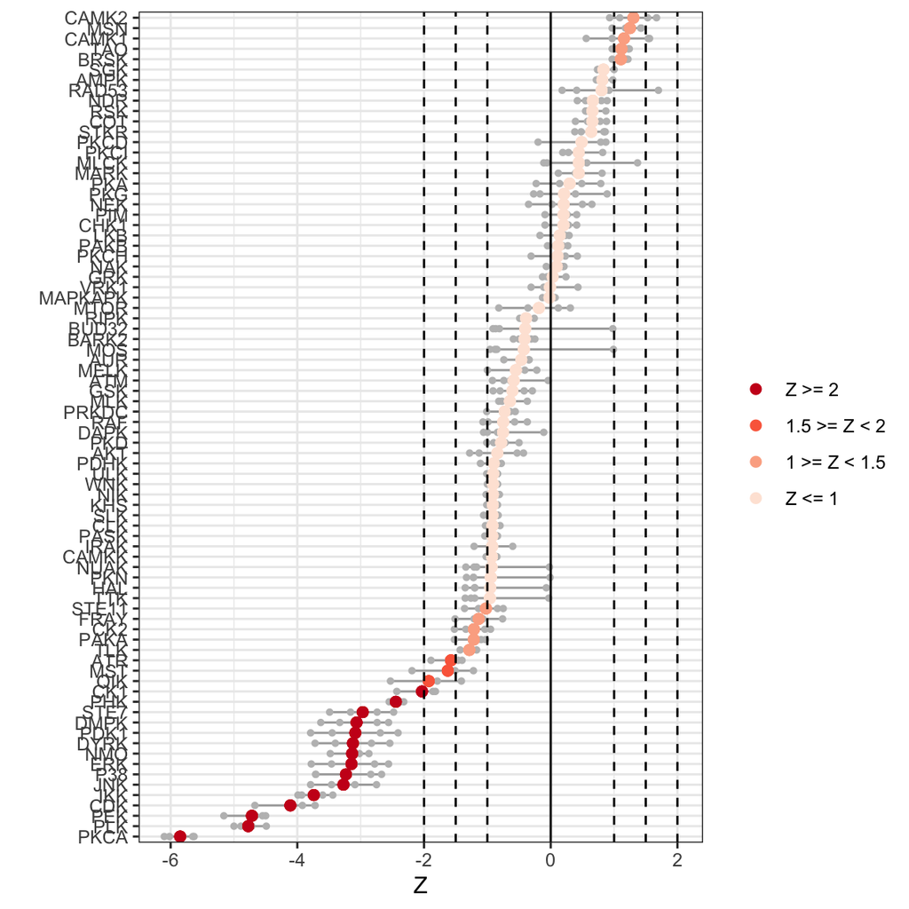

Waterfall plot of the Z Scores of each kinase family

#### Reverse KRSA Plot

We will use the reverse KRSA plot function, to plot the log2 fold change values for all peptides mapped to kinase hits. This will help us examine the activity of the kinase

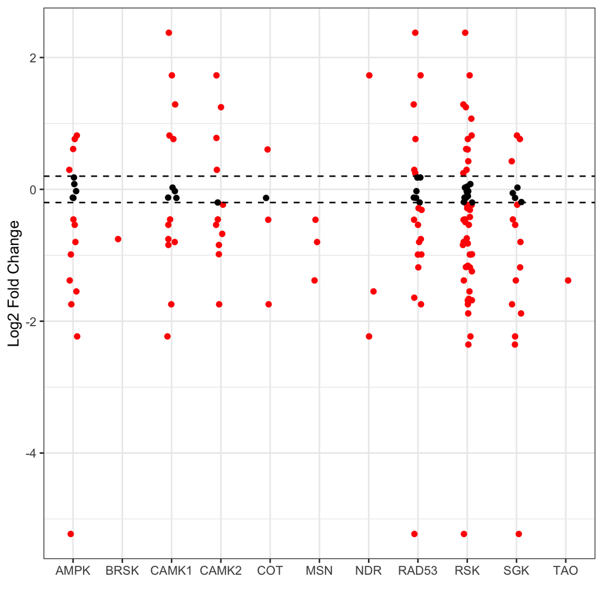

Kinase Activity summary for each kinase family based on peptide phosphorylation

#### Coverage Plot

To view the coverage of kinases across the full list of peptides on the chip, we will use the coverage plot function

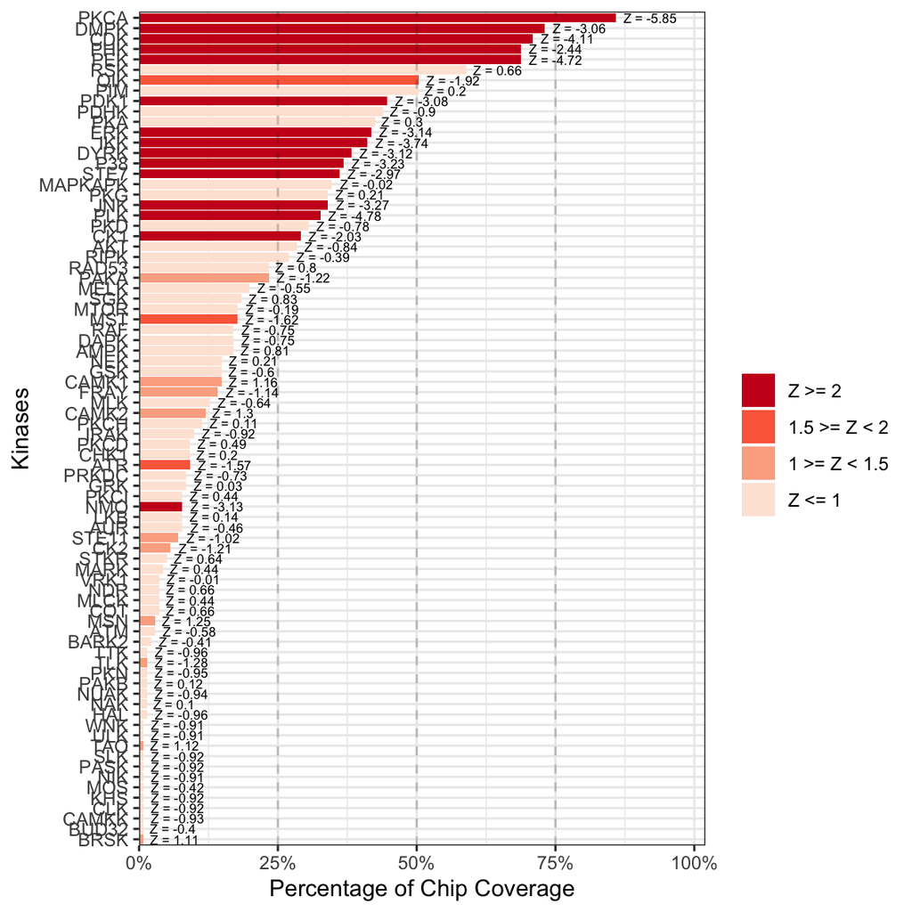

Percentage of peptides each kinase family phosphorylates

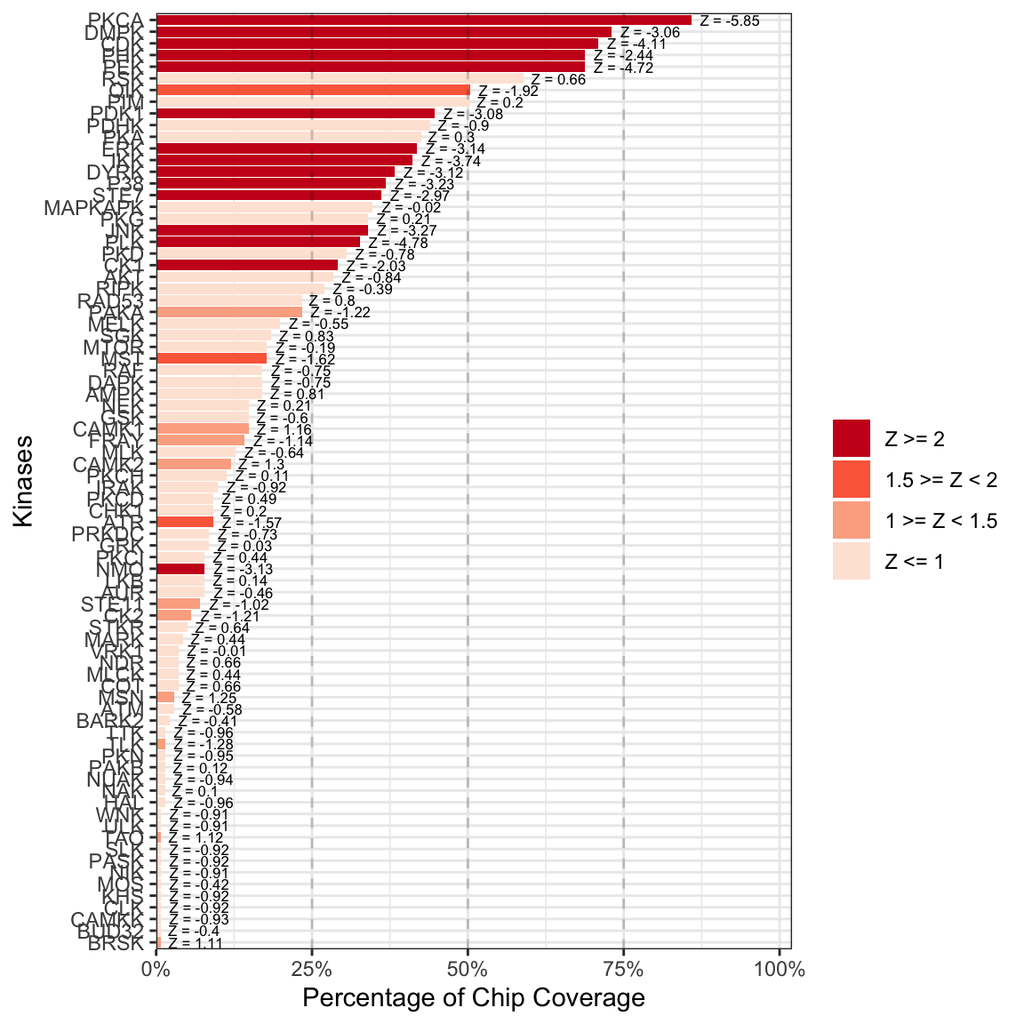

Percentage of peptides each kinase family phosphorylates

#### Ball Model Network

We will view the ball model network function, to generate a model representing the protein-protein interactions between kinases

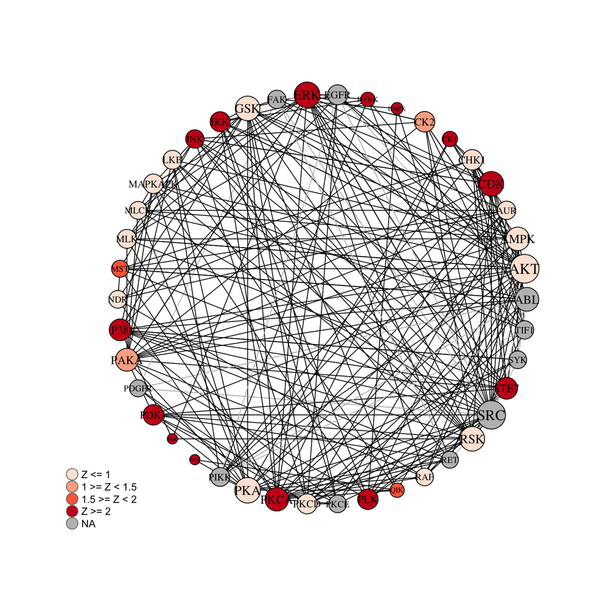

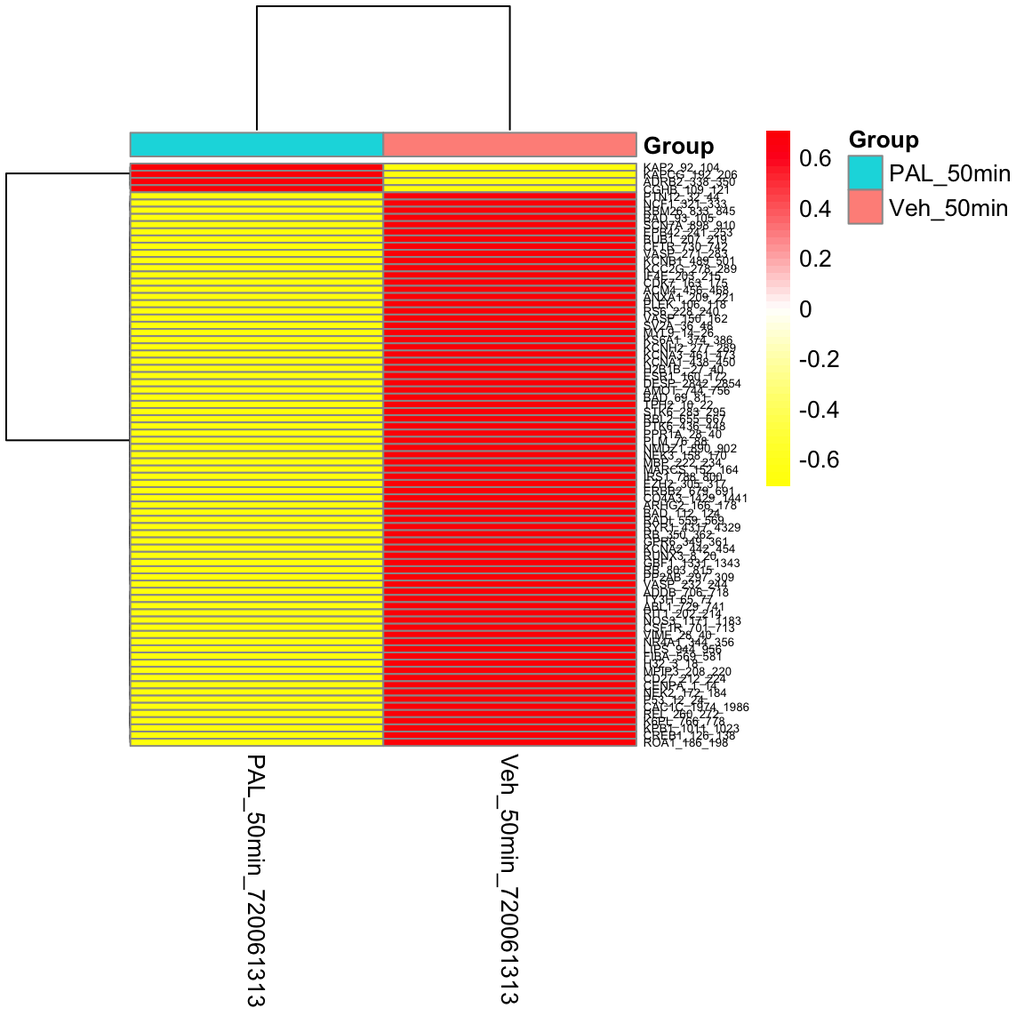

Heatmap of pairwise group comparison

### PAL_50min vs Veh_50min

#### Heatmap

After applying the *Filtering Parameters* for this group comparison, only *81*/141 peptides carried forward in the analysis (i.e. *81 hits*). Below are some figures to visualize the differences between these samples for considering these *hits*.

#### Violin Plot

Below, the violin plot visualizes the distribution of selected peptides for the analysis.

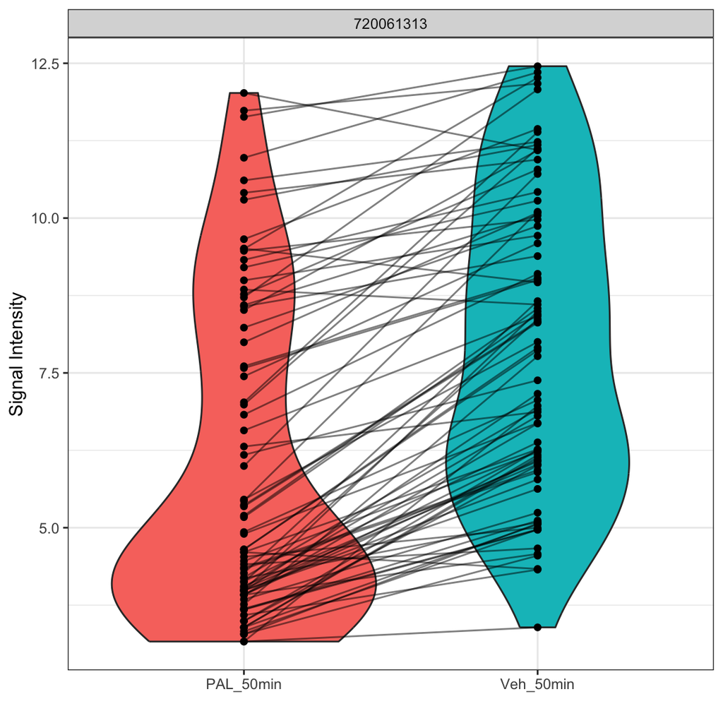

Violin plot of two groups

#### Waterfall Plot

This waterfall represents the log2 fold changes between the two groups at each peptide.

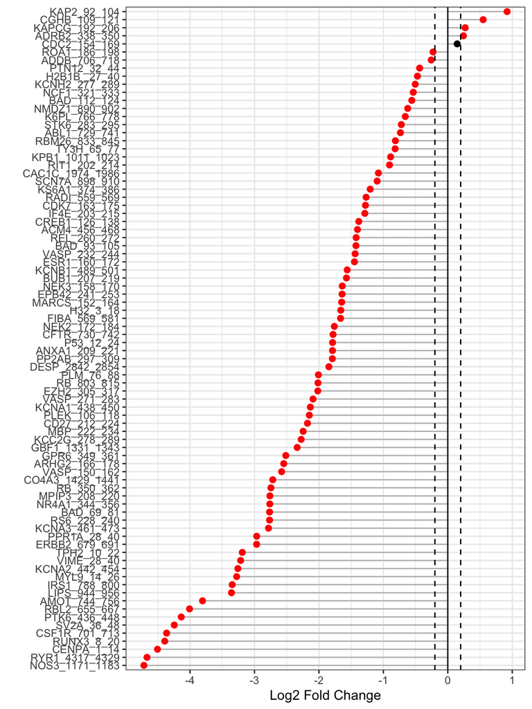

Waterfall Plot to show the distribution of change in peptide phosphorylation

#### Upstream Kinase Analysis

The lab carefully curated and mapped the kinases that can act and phosphorylate each peptide present on the chip. This was achieved by using multiple sources including GPS 3.0, Kinexus Phosphonet, PhosphoELM and PhosphoSite Plus. Based on that association between peptides and kinases, a random sampling analysis is performed for these hits. The basic idea of *KRSA* is: For each iteration (*2000* iterations performed in this analysis), the same number of hits are randomly selected from the total 141/or 193 peptides present on the chip. Predicted kinases are then mapped to this sample list of peptides and number of kinases are determined. The kinase count from the actual hits and random sampling is then compared to determine the significance.

| Kinase | AvgZ |
| --- | --- |
| PKCI | 2.100 |
| PKG | 1.990 |
| RAD53 | 1.815 |
| PKCD | 1.585 |
| CAMK1 | 1.320 |
| PKA | 1.305 |
| PAKB | 1.260 |
| HAL | 1.245 |
| AMPK | 1.135 |
| COT | 1.100 |
| NMO | -3.950 |
| JNK | -4.100 |
| P38 | -4.390 |
| PDK1 | -4.515 |
| PEK | -4.770 |
| PLK | -4.800 |
| DYRK | -4.915 |
| CDK | -5.405 |
| ERK | -5.605 |
| PKCA | -6.335 |

| Method | NumberOfPeptides |
| --- | --- |
| meanLFC.0.15 | 81 |
| meanLFC.0.2 | 81 |
| meanLFC.0.3 | 77 |
| meanLFC.0.4 | 77 |
| 720061313.0.15 | 81 |
| 720061313.0.2 | 81 |
| 720061313.0.3 | 77 |
| 720061313.0.4 | 77 |